# Temperature and mortality in Chicago: Piecewise linear analysis

Garyfallos Konstantinoudis

In this document we will show how to fit piecewise linear models in a Bayesian framework using `NIMBLE` (de Valpine et al. 2017). We will use the Chicago dataset as it can be found in the `dlnm` package. Using typing `help(chicagoNMMAPS)` you will find the following information about the dataset:

The data set contains daily mortality (all causes, CVD, respiratory), weather (temperature, dew point temperature, relative humidity) and pollution data (PM10 and ozone) for Chicago in the period 1987-2000 from the National Morbidity, Mortality and Air Pollution Study (NMMAPS).

The purpose of the tutorial is to assess the effect of temperature on the number of deaths of all causes, using the Chicago dataset. At this analysis we are not interested in modelling the lag effect.

## Install and load packages

This practical requires the following packages to be installed and attached: `sf`, `dplyr`, `tidyverse`, `nimble`, `coda`, `spdep`, `patchwork`, `GGally`, `ggmcmc`, `kableExtra`, `splines2` and `dlnm`.

- To install the entire suite of packages, we can use:

```r
install.packages(c("sf", "dplyr", "tidyverse", "nimble", "coda", "spdep", "patchwork",
                   "GGally", "ggmcmc", "dlnm", "splines2", "kableExtra"), dependencies = TRUE, repos = "http://cran.r-project.org")
```

- Then, load the needed packages:

```r
library(sf)           # Simple feature for R
library(dplyr)        # A package for data manipulation
library(tidyverse)    # A package for data manipulation and plotting
library(nimble)       # A package for performing MCMC in R
library(coda)         # A package for summarizing and plotting of MCMC output
                      # and diagnostic tests
library(spdep)        # A package to calculate neighbors
library(patchwork)    # A package to combine plots
library(GGally)       # A package to do pairplots
library(ggmcmc)       # MCMC diagnostics with ggplot
library(dlnm)         # A package for performing dlnms in R
library(splines2)     # A package to fit splines in R
library(kableExtra)   # packages for formatting tables in rmarkdown
library(fastDummies)  # Library to create dummies from a string
library(parallel)     # Library for parallel computing
```

## Import and explore the Chicago dataset

- Import the health data

```r
head(chicagoNMMAPS, 10)
```

```
##          date time year month doy       dow death cvd resp       temp   dptp
## 1  1987-01-01    1 1987     1   1  Thursday   130  65   13 -0.2777778 31.500
## 2  1987-01-02    2 1987     1   2    Friday   150  73   14  0.5555556 29.875
## 3  1987-01-03    3 1987     1   3  Saturday   101  43   11  0.5555556 27.375
## 4  1987-01-04    4 1987     1   4    Sunday   135  72    7 -1.6666667 28.625
## 5  1987-01-05    5 1987     1   5    Monday   126  64   12  0.0000000 28.875
## 6  1987-01-06    6 1987     1   6   Tuesday   130  63   12  4.4444444 35.125
## 7  1987-01-07    7 1987     1   7 Wednesday   129  72   12  1.3888889 26.750
## 8  1987-01-08    8 1987     1   8  Thursday   109  51   13 -1.6666667 22.000
## 9  1987-01-09    9 1987     1   9    Friday   125  62    7 -3.0555556 29.000
## 10 1987-01-10   10 1987     1  10  Saturday   153  90   11  0.2777778 27.750
##      rhum     pm10        o3
## 1  95.500 26.95607  4.376079
## 2  88.250       NA  4.929803
## 3  89.500 32.83869  3.751079
## 4  84.500 39.95607  4.292746
## 5  74.500       NA  4.751079
## 6  77.375 40.95607  6.334412
## 7  74.500 33.95607  8.594019
## 8  77.875 28.95607 11.797890
## 9  95.125 32.34877  3.876079
## 10 81.875       NA  5.388137
```

## Piecewise linear analysis

### The model

where $\alpha$ is an intercept term, $\beta_j$ covariates for the effect of the days, $\gamma$ a linear term for PM and $\xi_t$ a temporal trend. In this parametrization, $\alpha - c\beta_{\text{temp}1}$ and $\beta_{\text{temp}1}$ are the intercept and slope of the first line, whereas $\alpha - c\beta_{\text{temp}2}$ and $\beta_{\text{temp}2}$ the intercept and slope of the second line. The challenging part of such analyses is to specify this threshold.

In this tutorial, we will select thresholds in two ways and compare results. The first is by selecting the model with the threshold that minimises the WAIC, whereas the second is to treat the threshold as a random variable and calculate it accordingly.

## Minimising the WAIC

### The code

- Nimble model

```r
WAIC.code <- nimbleCode(
  {
    for (t in 1:Total){

      O[t] ~ dpois(mu[t])

      log(mu[t]) <- alpha + inprod(beta[1:6], X[t, 1:6]) + gamma*PM[t] + xi[time_cat[t]] +
        beta_tmp[J[t]] * (Temperature[t] - x.change)

      J[t] <- 1 + step(Temperature[t] - x.change)

    }

   # intrinsic CAR prior on the effect of time
   xi[1:N] ~ dcar_normal(adj[1:M], weights[1:M], num[1:N], tau.xi, c = 2, zero_mean = 1)


    # Priors:
    alpha ~ dnorm(0, tau = 0.001)
    alpha_1 <- alpha - beta_tmp[1]*x.change   # the intercept of the first segment
    alpha_2 <- alpha - beta_tmp[2]*x.change   # the intercept of the second segment

    for(j in 1:6){
        beta[j] ~ dnorm(0, tau = 5)
    }

    for (k in 1:2) {
      beta_tmp[k] ~ dnorm(0, tau = 5)
    }

    gamma ~ dnorm(0, tau = 5)

    # the priors are informative to help smoothing
    tau.xi <- 1/sigma2.xi
    sigma2.xi ~ dgamma(1, 0.5)
  }
)
```

- Define a new data frame without the missing PM$_{10}$.

```r
dat.complete.case <- chicagoNMMAPS[!is.na(chicagoNMMAPS$pm10),]
dat.complete.case <- dat.complete.case[order(dat.complete.case$time),]
dat.complete.case$time <- 1:nrow(dat.complete.case)

dat.complete.case$time_cat <- cut(
  dat.complete.case$time,
  breaks = seq(from = min(dat.complete.case$time),
               to  = max(dat.complete.case$time),
               length.out = 700), # a weekly term
  labels = 1:699,
  include.lowest = TRUE
)

dat.complete.case$time_cat <-
  as.numeric(droplevels(dat.complete.case$time_cat))

dat.complete.case <- dat.complete.case[order(dat.complete.case$time_cat),]
```

- Define the weights for the covariance matrix of the RW2.

```r
RW2 <- function(k){

    rest.comp <- list()
    for(i in 3:(k-2)){
      rest.comp[[i]] <- c(i-2, i-1, i+1, i+2)
    }
    rest.comp <- unlist(rest.comp)

    adj = c(2, 3, 1, 3, 4,
            rest.comp,
            c(k-3, k-2, k, k-2, k-1)
            )

    num = c(2, 3, rep(4, times = c(k-4)), 3, 2)

    weights = c(c(2, -1, 2, 4, -1),
                rep(c(-1, 4, 4, -1), times = c(k-4)),
                c(-1, 4, 2, -1, 2))

    retlist <- list()
    retlist$adj <- adj
    retlist$num <- num
    retlist$weights <- weights
    return(retlist)

}

# time
N <- max(dat.complete.case$time_cat)
Wnb <- RW2(N)
```

- Data objects:

```r
# Format the data for NIMBLE in a list
ChicagoData = list(
                 O = dat.complete.case$death,
                 X = as.matrix(fastDummies::dummy_cols(dat.complete.case$dow)[,-c(1:2)]),
                 PM = scale(dat.complete.case$pm10)[,1],
                 Temperature = dat.complete.case$temp

)

ChicagoConsts <-list(
                 N = N,
                 M = length(Wnb$adj),

                 adj = Wnb$adj,
                 num = Wnb$num,
                 weights = Wnb$weights,

                 time_cat = dat.complete.case$time_cat,
                 Total = nrow(dat.complete.case)
)
```

- Initialize the parameters:

```r
inits <-
  list(alpha=rep(0.01, times = 1),
       sigma2.xi=0.1,
       xi=rep(0.1, times = N),
       beta=rep(0, times = 6),
       gamma=0,
       beta_tmp=rep(0, times = 2))
```

- Set the parameters that will be monitored:

```r
params <- c("mu", paste0("beta[", 1:6, "]"), "alpha", "alpha_1", "alpha_2",
            "gamma", "xi", "sigma2.xi", paste0("beta_tmp[", 1:2, "]"))
```

- Specify the MCMC setting:

```r
# MCMC setting
ni <- 150000  # nb iterations
nt <- 10     # thinning interval
nb <- 50000   # nb iterations as burn-in
nc <- 1      # nb chains
```

- Run the MCMC simulations calling Nimble from R using the function `nimbleMCMC()`. If implemented on the parallel environment takes ~1h.

```r
thresholds <- quantile(dat.complete.case$temp, probs = seq(from = 0.05, to = 0.95, by = 0.05))
```

```r
parfun <- function(m){

  ChicagoConsts$x.change <- as.numeric(thresholds[m])

  WAIC.model <- nimbleMCMC(code = WAIC.code,
                           data = ChicagoData,
                           constants = ChicagoConsts,
                           inits = inits,
                           monitors = params,
                           niter = ni,
                           nburnin = nb,
                           thin = nt,
                           nchains = nc,
                           setSeed = 9,
                           progressBar = TRUE,
                           samplesAsCodaMCMC = TRUE,
                           summary = TRUE,
                           WAIC = TRUE
  )

  WAIC_vals <- WAIC.model$WAIC
  beta_1 <- WAIC.model$summary["beta_tmp[1]", c("Median", "95%CI_low", "95%CI_upp")]
  beta_2 <- WAIC.model$summary["beta_tmp[2]", c("Median", "95%CI_low", "95%CI_upp")]

  list2ret <- list(WAIC_vals = WAIC_vals, beta_1 = beta_1, beta_2 = beta_2)
  return(list2ret)
}



# Set up parallel environment
m <- 1:19
ncores <- 19
cl <- makeCluster(ncores, methods=FALSE)

clusterEvalQ(cl, {
  library(nimble)
})

clusterExport(cl, c("parfun", "thresholds", "WAIC.code", "ChicagoData", "ChicagoConsts",
                    "inits", "params", "ni", "nb", "nc", "nt", "m"))


# For 1 parameter use parSapply
t_0 <- Sys.time()
outpar <- parLapply(cl = cl, m, parfun)
t_1 <- Sys.time()
t_1 - t_0

# close parallel environment
stopCluster(cl)
```

- Extract the threshold that minimises the WAIC.

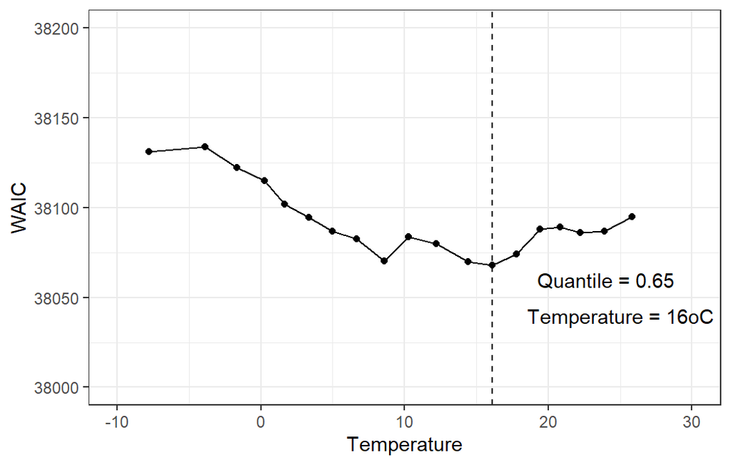

```r
dat_WAIC <- data.frame(quant = seq(from = 0.05, to = 0.95, by = 0.05),
                       thresholds = thresholds,
                       WAIC = sapply(outpar, function(X) X$WAIC_vals))


dat_WAIC %>%  slice(which.min(WAIC)) -> minWAIC
ggplot() + geom_point(data = dat_WAIC, aes(x=thresholds, y = WAIC)) +
  geom_line(data = dat_WAIC, aes(x=thresholds, y = WAIC)) + ylim(c(38000, 38200)) + xlim(c(-10, 30)) +
  theme_bw() + xlab("Temperature") + geom_vline(data = minWAIC, aes(xintercept = thresholds), linetype = "dashed") +
  annotate("text", x = 24, y = 38060, label = paste0("Quantile = ", minWAIC$quant)) +
  annotate("text", x = 25, y = 38040, label = paste0("Temperature = ", round(minWAIC$thresholds), "oC"))
```

- Extract $\beta_{\text{temp}1}$ and $\beta_{\text{temp}2}$ for the different thresholds. In red dotted line is the threshold that minimises the WAIC.

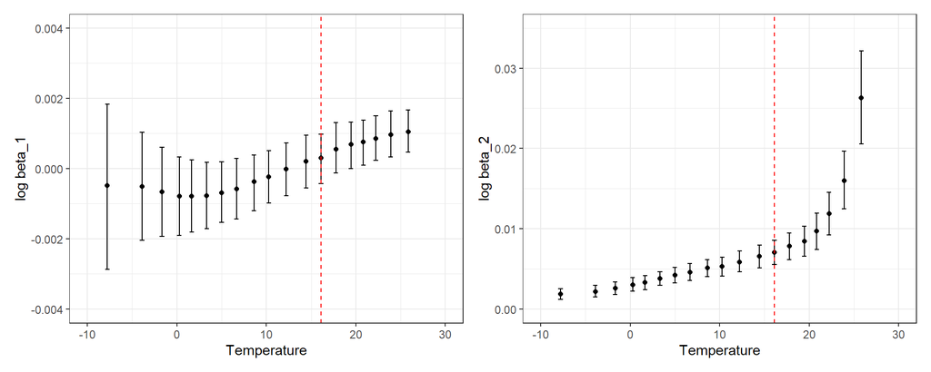

```r
# beta_1
dat_beta1 <- data.frame(quant = seq(from = 0.05, to = 0.95, by = 0.05),
                        thresholds = thresholds)
dat_beta1 <- cbind(dat_beta1, do.call(rbind, lapply(outpar, function(X) X$beta_1)))
colnames(dat_beta1)[c(4:5)] <- c("low", "up")

ggplot() +
  geom_point(data = dat_beta1, aes(x = thresholds, y = Median)) +
  geom_errorbar(data = dat_beta1, aes(x = thresholds, y = Median, ymin = low, ymax = up),
                width = .5, position = "dodge") + ylim(c(-0.004, 0.004)) + xlim(c(-10, 30)) +
  xlab("Temperature") + ylab("log beta_1") + theme_bw() +
  geom_vline(data = minWAIC, aes(xintercept = thresholds), linetype = "dashed", col = "red") -> p1


# beta_2
dat_beta2 <- data.frame(quant = seq(from = 0.05, to = 0.95, by = 0.05),
                        thresholds = thresholds)
dat_beta2 <- cbind(dat_beta2, do.call(rbind, lapply(outpar, function(X) X$beta_2)))
colnames(dat_beta2)[c(4:5)] <- c("low", "up")

ggplot() +
  geom_point(data = dat_beta2, aes(x = thresholds, y = Median)) +
  geom_errorbar(data = dat_beta2, aes(x = thresholds, y = Median, ymin = low, ymax = up),
                width = .5, position = "dodge") + ylim(c(0, 0.035)) + xlim(c(-10, 30)) +
  xlab("Temperature") + ylab("log beta_2") + theme_bw() +
  geom_vline(data = minWAIC, aes(xintercept = thresholds), linetype = "dashed", col = "red") -> p2

p1|p2
```

- Table of the WAIC, different thresholds and the betas. The difference between the WAICs of the 45th, 60th and 65th percentile is negligible, but strictly speaking the minimum is for the 65th.

```r
options(scipen = 9999999)
dat <- cbind(round(dat_WAIC$WAIC),
             signif(cbind(dat_WAIC[,-3], dat_beta1[,-c(1,2)], dat_beta2[,-c(1,2)]), 2))

colnames(dat)[1] <- "WAIC"
dat <- rbind(

  c("", "", "", "", "beta_1", "", "", "beta_2", ""),
  colnames(dat),
  dat

)

colnames(dat) <- NULL

knitr::kable(dat) %>%
  kable_styling(bootstrap_options = "striped", full_width = F, position = "center")
```

| 1 |  |  |  |  | beta_1 |  |  | beta_2 |  |
| --- | --- | --- | --- | --- | --- | --- | --- | --- | --- |
| 2 | WAIC | quant | thresholds | Median | low | up | Median | low | up |
| 5% | 38131 | 0.05 | -7.8 | -0.00049 | -0.0029 | 0.0018 | 0.0019 | 0.0012 | 0.0025 |
| 10% | 38134 | 0.1 | -3.9 | -0.00051 | -0.002 | 0.001 | 0.0022 | 0.0015 | 0.003 |
| 15% | 38122 | 0.15 | -1.7 | -0.00067 | -0.0019 | 0.00061 | 0.0026 | 0.0018 | 0.0034 |
| 20% | 38115 | 0.2 | 0.28 | -0.00079 | -0.0019 | 0.00032 | 0.003 | 0.0022 | 0.0039 |
| 25% | 38102 | 0.25 | 1.7 | -0.00079 | -0.0018 | 0.00024 | 0.0033 | 0.0024 | 0.0042 |
| 30% | 38094 | 0.3 | 3.3 | -0.00077 | -0.0017 | 0.00017 | 0.0038 | 0.003 | 0.0046 |
| 35% | 38087 | 0.35 | 5 | -0.00069 | -0.0015 | 0.00019 | 0.0042 | 0.0033 | 0.0052 |
| 40% | 38083 | 0.4 | 6.7 | -0.00058 | -0.0014 | 0.00028 | 0.0046 | 0.0036 | 0.0056 |
| 45% | 38070 | 0.45 | 8.6 | -0.00037 | -0.0012 | 0.00039 | 0.0051 | 0.004 | 0.0062 |
| 50% | 38084 | 0.5 | 10 | -0.00023 | -0.00099 | 0.00051 | 0.0053 | 0.0041 | 0.0064 |
| 55% | 38080 | 0.55 | 12 | -0.000012 | -0.00077 | 0.00073 | 0.0058 | 0.0046 | 0.0072 |
| 60% | 38070 | 0.6 | 14 | 0.00021 | -0.00055 | 0.00095 | 0.0066 | 0.0051 | 0.0079 |
| 65% | 38068 | 0.65 | 16 | 0.0003 | -0.00043 | 0.00097 | 0.007 | 0.0055 | 0.0085 |
| 70% | 38074 | 0.7 | 18 | 0.00055 | -0.00013 | 0.0013 | 0.0078 | 0.0062 | 0.0095 |
| 75% | 38088 | 0.75 | 19 | 0.00069 | -0.0000023 | 0.0013 | 0.0084 | 0.0066 | 0.01 |
| 80% | 38089 | 0.8 | 21 | 0.00075 | 0.000098 | 0.0014 | 0.0097 | 0.0074 | 0.012 |
| 85% | 38086 | 0.85 | 22 | 0.00085 | 0.00023 | 0.0015 | 0.012 | 0.0092 | 0.015 |
| 90% | 38087 | 0.9 | 24 | 0.00096 | 0.00033 | 0.0016 | 0.016 | 0.012 | 0.02 |
| 95% | 38095 | 0.95 | 26 | 0.001 | 0.00046 | 0.0017 | 0.026 | 0.021 | 0.032 |

- Rerun the model with the threshold identified

```r
inits <- list(

  list(alpha=0.01,
       sigma2.xi=0.1,
       xi=rep(0.1, times = N),
       beta=rep(0, times = 6),
       gamma=0,
       beta_tmp=rep(0, times = 2)),

  list(alpha=1,
       sigma2.xi=1,
       xi=rep(0.5, times = N),
       beta=rep(-1, times = 6),
       gamma=2,
       beta_tmp=rep(1, times = 2))
)

nc <- 2

ChicagoConsts$x.change <- minWAIC$thresholds

WAIC.model <- nimbleMCMC(code = WAIC.code,
                           data = ChicagoData,
                           constants = ChicagoConsts,
                           inits = inits,
                           monitors = params,
                           niter = ni,
                           nburnin = nb,
                           thin = nt,
                           nchains = nc,
                           setSeed = 9,
                           progressBar = TRUE,
                           samplesAsCodaMCMC = TRUE,
                           summary = TRUE,
                           WAIC = TRUE
  )
```

### Convergence

- Check convergence

```r
ggs_mod_WAIC <- ggs(WAIC.model$samples)
```

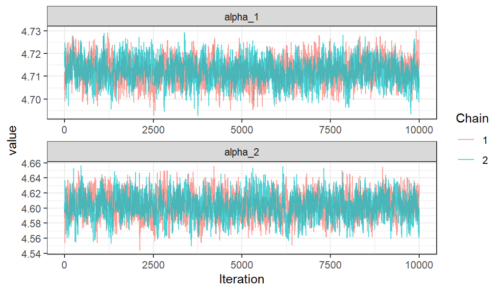

```r
ggs_mod_WAIC %>% filter(Parameter %in% c("alpha_1", "alpha_2")) %>%
  ggs_traceplot() + theme_bw()
```

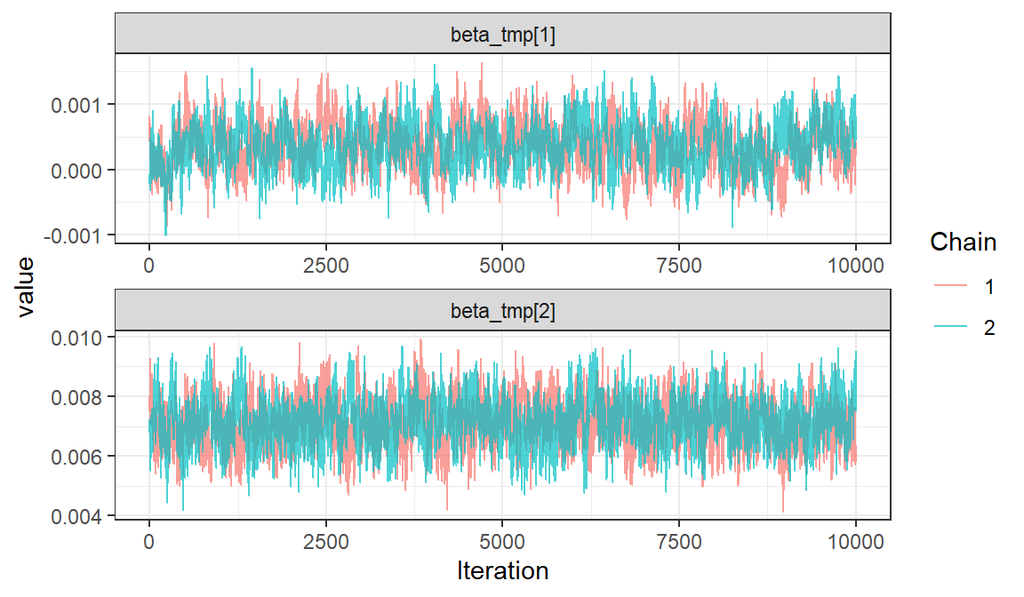

```r
ggs_mod_WAIC %>% filter(Parameter %in% c(paste0("beta_tmp[", 1:2, "]"))) %>%
  ggs_traceplot() + theme_bw()
```

## Threshold as random variable

### The code

- Nimble model

```r
Changepoint.code <- nimbleCode(
  {
    for (t in 1:Total){

      O[t] ~ dpois(mu[t])

      log(mu[t]) <- alpha + inprod(beta[1:6], X[t, 1:6]) + gamma*PM[t] + xi[time_cat[t]] +
        beta_tmp[J[t]] * (Temperature[t] - x.change)

      J[t] <- 1 + step(Temperature[t] - x.change)
    }

    # intrinsic CAR prior on the effect of time
   xi[1:N] ~ dcar_normal(adj[1:M], weights[1:M], num[1:N], tau.xi, c = 2, zero_mean = 1)


    # Priors:
    alpha ~ dnorm(0, tau = 0.001)
    alpha_1 <- alpha - beta_tmp[1]*x.change   # the intercept of the first segment
    alpha_2 <- alpha - beta_tmp[2]*x.change   # the intercept of the second segment

    for(j in 1:6){
        beta[j] ~ dnorm(0, tau = 5)
    }

    for (k in 1:2) {
      beta_tmp[k] ~ dnorm(0, tau = 5)
    }

    gamma ~ dnorm(0, tau = 5)

    # the priors are informative to help smoothing
    tau.xi <- 1/sigma2.xi
    sigma2.xi ~ dgamma(1, 0.5)

    x.change ~ dunif(-26,33)                 #  tuned based on the max and min

  }
)
```

- Initialize the parameters:

```r
inits <- list(

  list(alpha=0.01,
       sigma2.xi=0.1,
       xi=rep(0.1, times = N),
       beta=rep(0, times = 6),
       gamma=0,
       x.change=10,
       beta_tmp=rep(0, times = 2)),

  list(alpha=1,
       sigma2.xi=1,
       xi=rep(0.5, times = N),
       beta=rep(-1, times = 6),
       gamma=2,
       x.change=20,
       beta_tmp=rep(1, times = 2))
)
```

- Set the parameters that will be monitored:

```r
params <- c("mu", paste0("beta[", 1:6, "]"), "alpha", "alpha_1","alpha_2",
            "gamma", "xi", "sigma2.xi", paste0("beta_tmp[", 1:2, "]"),
            "x.change")
```

- Specify the MCMC setting:

```r
# MCMC setting
ni <- 150000  # nb iterations
nt <- 10     # thinning interval
nb <- 50000   # nb iterations as burn-in
nc <- 2      # nb chains
```

- Run the MCMC simulations calling Nimble from R using the function `nimbleMCMC()`. (1.7 hours)

```r
ChicagoConsts$x.change <- NULL

t_0 <- Sys.time()
Changepoint.model <- nimbleMCMC(code = Changepoint.code,
                      data = ChicagoData,
                      constants = ChicagoConsts,
                      inits = inits,
                      monitors = params,
                      niter = ni,
                      nburnin = nb,
                      thin = nt,
                      nchains = nc,
                      setSeed = 9,
                      progressBar = TRUE,
                      samplesAsCodaMCMC = TRUE,
                      summary = TRUE,
                      WAIC = TRUE
                      )
t_1 <- Sys.time()
time_cp <- t_1 - t_0
```

### Convergence

- Check convergence

```r
ggs_mod_cp <- ggs(Changepoint.model$samples)
```

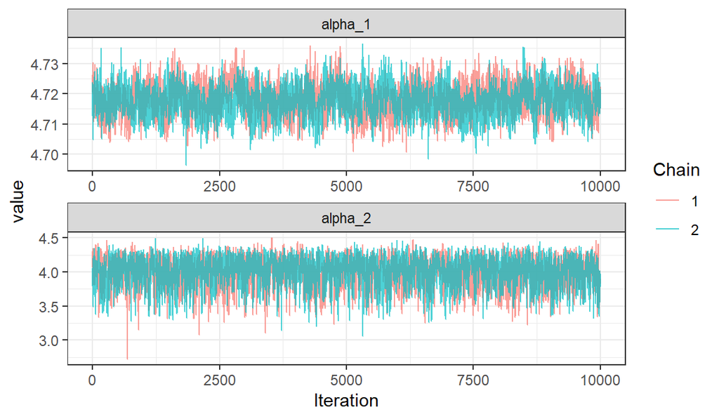

```r
ggs_mod_cp %>% filter(Parameter %in% c( "alpha_1", "alpha_2")) %>%
  ggs_traceplot() + theme_bw()
```

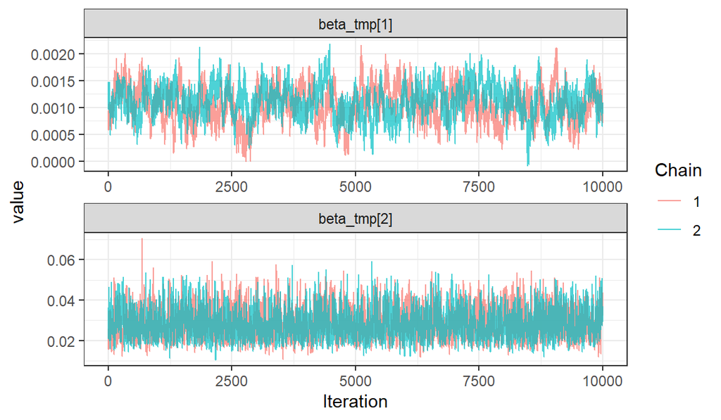

```r
ggs_mod_cp %>% filter(Parameter %in% c(paste0("beta_tmp[", 1:2, "]"))) %>%
  ggs_traceplot() + theme_bw()
```

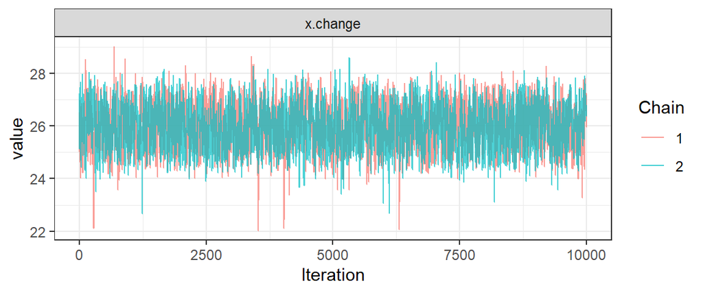

```r
ggs_mod_cp %>% filter(Parameter %in% c("x.change")) %>%
  ggs_traceplot() + theme_bw()
```

## Comparison of Results

The model with threshold as a random variable picks up a higher threshold (see histogram below) compared to the one picked up by the WAIC procedure (red dashed line below). I should also note that I rerun the analysis for the changepoint model with different initial values for the x.change, namely 0 and -10, and the results are identical.

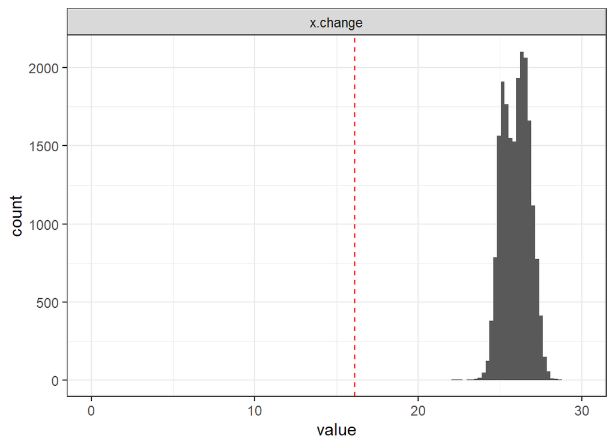

```r
ggs_mod_cp %>% filter(Parameter %in% c("x.change")) %>%
  ggs_histogram() + theme_bw() + geom_vline(data = minWAIC, aes(xintercept = thresholds),
                                            linetype = "dashed", col = "red") + xlim(c(0,30))
```

- Table of results. The results based on the different approaches are a bit different, of course due to the different change points selected.

```r
Coef95CrI <- function(mod){

  a_1 <- signif(quantile(mod$samples$chain2[,"alpha_1"], probs = c(0.5, 0.025, 0.975)), digits = 4)
  a_2 <- signif(quantile(mod$samples$chain2[,"alpha_2"], probs = c(0.5, 0.025, 0.975)), digits = 4)

  a.bind <-
    rbind(
      cbind(
        paste0(a_1[1]),
        paste0("(", a_1[2], ", " , a_1[3], ")")
      ),
      cbind(
        paste0(a_2[1]),
        paste0("(", a_2[2], ", " , a_2[3], ")")
      )
    )

  b_1 <- signif(quantile(mod$samples$chain2[,"beta_tmp[1]"],
                         probs = c(0.5, 0.025, 0.975))*100, digits = 2)
  b_2 <- signif(quantile(mod$samples$chain2[,"beta_tmp[2]"],
                         probs = c(0.5, 0.025, 0.975))*100, digits = 2)

  b.bind <-
    rbind(
    cbind(
      paste0(b_1[1], "%"),
      paste0("(", b_1[2], "%", ", " , b_1[3], "%)")
    ),
    cbind(
      paste0(b_2[1], "%"),
      paste0("(", b_2[2], "%", ", " , b_1[3], "%)")
    )
  )

  dat <- data.frame(rbind(a.bind, b.bind))
  rownames(dat) <- c("alpha_1", "alpha_2", "beta_1*100", "beta_2*100")
  colnames(dat) <- c("Median", "CrI95%")
  return(dat)

}


tab <- cbind(Coef95CrI(WAIC.model), Coef95CrI(Changepoint.model))
tab <- rbind(

  c("WAIC", "", "Changepoint", ""),
  colnames(tab),
  tab

)

colnames(tab) <- NULL
rownames(tab)[c(1,2)] <- c("", " ")
knitr::kable(tab) %>%
  kable_styling(bootstrap_options = "striped",
                full_width = F, position = "center")
```

|  | WAIC |  | Changepoint |  |
| --- | --- | --- | --- | --- |
|  | Median | CrI95% | Median | CrI95% |
| alpha_1 | 4.712 | (4.703, 4.722) | 4.717 | (4.708, 4.727) |
| alpha_2 | 4.603 | (4.572, 4.632) | 4.044 | (3.555, 4.312) |
| beta_1*100 | 0.036% | (-0.03%, 0.11%) | 0.11% | (0.052%, 0.17%) |
| beta_2*100 | 0.72% | (0.57%, 0.11%) | 2.7% | (1.7%, 0.17%) |

- Plot a RW2 for the temperature (see [this tutorial](https://gkonstantinoudis.github.io/nimble/Missings.html)) and the 2 different threshold approaches. It seems that the changepoint model captures better the extremes observed in the higher temperatures, whereas the WAIC approach is defined in a way so there is a better representation of the effect of smaller temperatures.

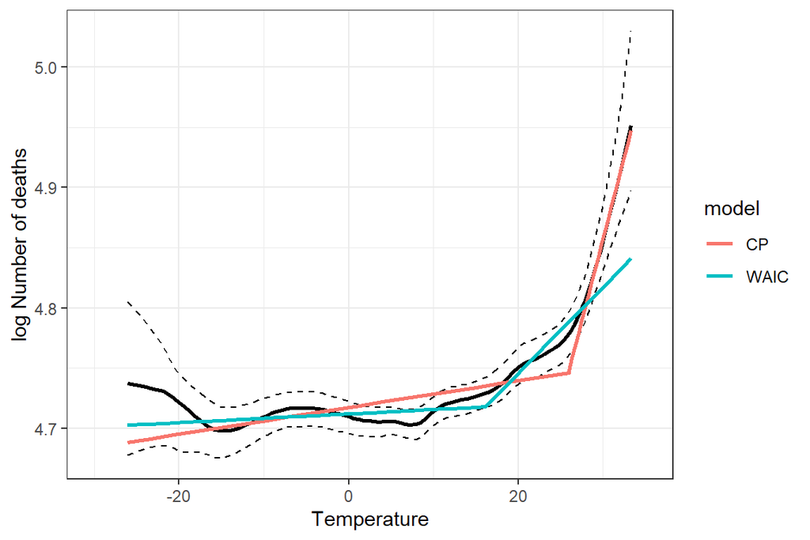

```r
tmp_cat = cut(
  dat.complete.case$temp,
  breaks = seq(from = min(dat.complete.case$temp),
               to  = max(dat.complete.case$temp),
               length.out = 100),
  labels = seq(from = min(dat.complete.case$temp),
               to  = max(dat.complete.case$temp),
               length.out = 100)[-1],
  include.lowest = TRUE
)

tmp_cat <- droplevels(tmp_cat)
tmp_cat <-
round(as.numeric(as.character(levels(tmp_cat))), digits = 3)
K <- length(tmp_cat)


datRW2 = data.frame(temp = tmp_cat,
                 median = RW2.model$summary$all.chains[paste0("w[", 1:K, "]"), "Median"] +
                   RW2.model$summary$all.chains["alpha","Median"],
                 LL = RW2.model$summary$all.chains[paste0("w[", 1:K, "]"), "95%CI_low"] +
                   RW2.model$summary$all.chains["alpha","Median"],
                 UL = RW2.model$summary$all.chains[paste0("w[", 1:K, "]"), "95%CI_upp"] +
                  RW2.model$summary$all.chains["alpha","Median"])



# function to get the lines to plot them


PlotLinearSegm <- function(mod, thr){

  a <- median(mod$samples$chain2[,"alpha"])
  b_1 <- median(mod$samples$chain2[,"beta_tmp[1]"])
  b_2 <- median(mod$samples$chain2[,"beta_tmp[2]"])

  a_1 <- median(mod$samples$chain2[,"alpha_1"])
  a_2 <- median(mod$samples$chain2[,"alpha_2"])

  x_1 <- seq(from=min(tmp_cat), to=thr, length.out = 20)
  x_2 <- seq(from=thr, to=max(tmp_cat), length.out = 20)

  return(data.frame(xvalues = c(x_1, x_2), beta = c(c(a_1 + b_1*x_1), c(a_2 + b_2*x_2))))

}


# WAIC model

dat.WAIC.plot <- PlotLinearSegm(mod=WAIC.model, thr=minWAIC$thresholds)
dat.WAIC.plot$model <- "WAIC"

# CP model

dat.cp.plot <- PlotLinearSegm(mod=Changepoint.model,
                              thr=median(Changepoint.model$samples$chain2[,paste0("x.change")]))

dat.cp.plot$model <- "CP"

dat.mod.plot <- rbind(dat.WAIC.plot, dat.cp.plot)


ggplot() + geom_line(data = datRW2, aes(x = temp, y = median), size = 1) +
  geom_line(data = datRW2, aes(x = temp, y = LL), linetype = 2) +
  geom_line(data = datRW2, aes(x = temp, y = UL), linetype = 2) +
  theme_bw() + xlab("Temperature") + ylab("log Number of deaths") + xlim(c(-30, 35)) +
  geom_line(data = dat.mod.plot, aes(x = xvalues, y = beta, col = model), linetype = 1, size = 1)
```

## References

de Valpine, P., D. Turek, C. J. Paciorek, C. Anderson-Bergman, D. Temple Lang, and R. Bodik. 2017. “Programming with Models: Writing Statistical Algorithms for General Model Structures with NIMBLE.” *Journal of Computational and Graphical Statistics* 26: 403–17. https://doi.org/10.1080/10618600.2016.1172487.